# Assignment 1 - The tidyverse

Daniyar Imanaliev

September 26, 2023 | 03:39:44 | CEST

Daniyar2822

```r
library(legislatoR)
library(tibble)
library(tidyverse)
library(dplyr)
library(eeptools)
```

### Getting started with the Comparative Legislators Database

The Comparative Legislators Database (CLD) includes political, sociodemographic, career, online presence, public attention, and visual information for over 45,000 contemporary and historical politicians from ten countries (see the [corresponding article](https://www.cambridge.org/core/journals/british-journal-of-political-science/article/comparative-legislators-database/D28BB58A8B2C08C8593DB741F42C18B2) for more information). It can be accessed via `legislatoR` - an R package that is available on both [CRAN](https://cran.r-project.org/web/packages/legislatoR/index.html) and [GitHub](https://github.com/saschagobel/legislatoR).

Before you start with the following tasks, skim the tutorial to make yourself familiar with the database. You find it [here](https://cran.r-project.org/web/packages/legislatoR/vignettes/legislatoR.html).

For the following tasks, you will work with ONE of the legislatures. The legislature you’ll work with depends on your first name:

| Your first name starts with… | Legislature | Code |
| --- | --- | --- |
| A-C | Austrian Nationalrat | `aut` |
| D-F | Canadian House of Commons | `can` |
| G-I | Czech Poslanecka Snemovna | `cze` |
| J-L | Spanish Congreso de los Diputados | `esp` |
| M-O | French Assemblée | `fra` |
| P-R | German Bundestag | `deu` |
| S-U | Irish Dail | `irl` |
| V-X | UK House of Commons | `gbr` |
| Y-Z | US House of Representatives | `usa_house` |

The following tasks will be based on data from the `core` and `political` tables of the database.

### Task 1 - Descriptives

1. What’s the overall share of female legislators in the entire dataset?

```r
can_core <- get_core(legislature = 'can')
table(can_core$sex)
```

```
female   male
   376   4186
```

```r
gend <- data.frame(table(can_core$sex))
fem_share <- (gend$Freq[1] / gend$Freq[2]) * 100
fem_share <- round(fem_share, digits = 2)
cat("Overall share of women is:", fem_share, '%')
```

[output not shown]

2. How many (both in absolute and relative terms) legislators died in the same place they were born in?

```r
same_place <- data.frame(table(can_core$birthplace == can_core$deathplace))
num_names <- length(can_core$name)
same_place_num <- same_place$Freq[2]
cat("Absolute number of legislators died in the same place:", same_place_num)
```

```
Absolute number of legislators died in the same place: 152
```

```r
same_place_per <- same_place$Freq[2]/num_names * 100
same_place_per <- round(same_place_per, digits = 2)
cat("Relative number of legislators died in the same place:", same_place_per, "%")
```

```
Relative number of legislators died in the same place: 3.33 %
```

3. Create a new variable `age_at_death` that reports the age at which legislators died. Then, plot the distribution of that variable for the entire dataset.

```r
can_core$birth <- as.Date(can_core$birth) #switch to date format
can_core$death <- as.Date(can_core$death) #switch to date format
can_core2 <- data.frame(can_core) #creating standalone dataframe for manipulations
sum(is.na(can_core2$birth)) #counting NA values
```

```
[1] 65
```

```r
sum(is.na(can_core2$death)) #counting NA values
```

```
[1] 1470
```

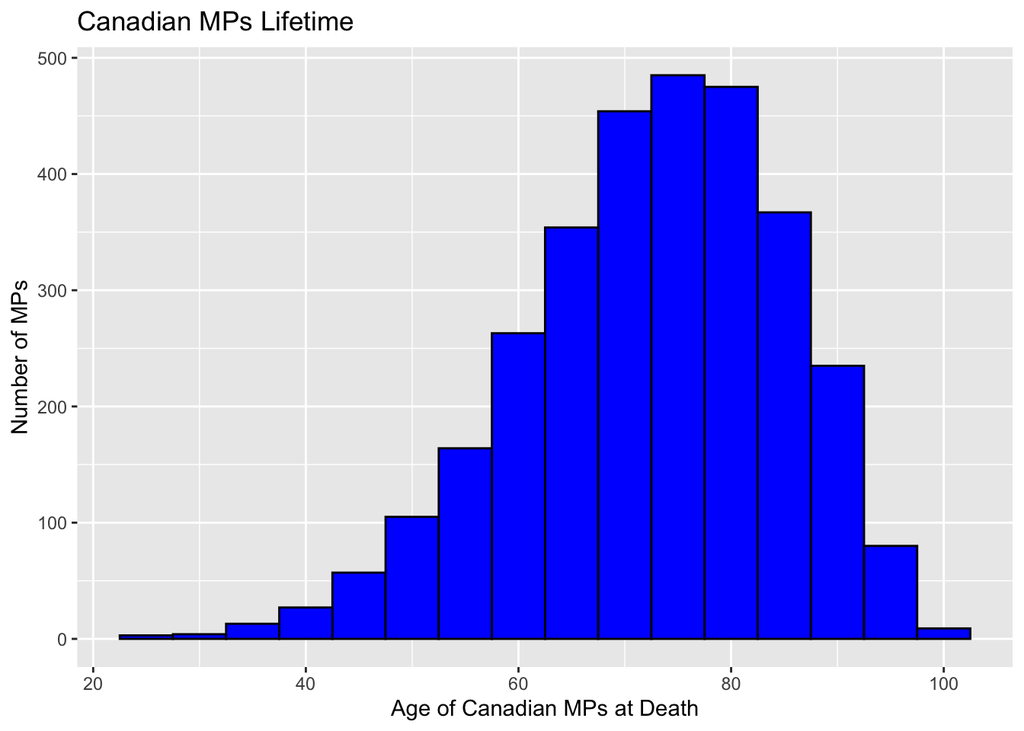

```r
can_core2 <- can_core2 %>% drop_na(death) #removing NA values from death column
can_core2 <- can_core2 %>% drop_na(birth) #removing NA values from birth column
can_core2$age_at_death <- age_calc(can_core2$birth, can_core2$death, units = 'years') #calculating age
can_core2$age_at_death <- floor(can_core2$age_at_death) # takes single numeric argument for creating plot
ggplot(can_core2, aes(x=age_at_death)) + geom_histogram(color="black", fill="blue",  binwidth=5) +
  labs(x = "Age of Canadian MPs at Death", y = "Number of MPs", title = "Canadian MPs Lifetime")
```

4. What is the most frequent birthday in your sample (e.g., “January 15”)?

```r
can_core$birthday <- can_core$birth #creating separate column "birthday"
can_core$birthday <- format(can_core$birthday, format="%m-%d") #modifying format removing years
table(can_core$birthday) #creating table from dataframe with birthdays only
```

```
01-01 01-02 01-03 01-04 01-05 01-06 01-07 01-08 01-09 01-10 01-11 01-12 01-13
  291    13    15    11    13    11    10    16     8    12    15     9     9
01-14 01-15 01-16 01-17 01-18 01-19 01-20 01-21 01-22 01-23 01-24 01-25 01-26
    9    14    11    12    16    10    15     8    12    10    10    13    13
01-27 01-28 01-29 01-30 01-31 02-01 02-02 02-03 02-04 02-05 02-06 02-07 02-08
   11    11    14     6     5    16     8    11    13    13    12     7    10
02-09 02-10 02-11 02-12 02-13 02-14 02-15 02-16 02-17 02-18 02-19 02-20 02-21
    9     7    13    12    22    18    12    12    17    18    12     7    10
02-22 02-23 02-24 02-25 02-26 02-27 02-28 02-29 03-01 03-02 03-03 03-04 03-05
    7    11     8    12     9    14    12     3    17    11    13    14    11
03-06 03-07 03-08 03-09 03-10 03-11 03-12 03-13 03-14 03-15 03-16 03-17 03-18
   11    17     9    10    18    12    15    11    13    12    10    13     7
03-19 03-20 03-21 03-22 03-23 03-24 03-25 03-26 03-27 03-28 03-29 03-30 03-31
   10    12    11    14     7    15    14    16    14     8     6    13    11
04-01 04-02 04-03 04-04 04-05 04-06 04-07 04-08 04-09 04-10 04-11 04-12 04-13
   12    10    10    10     8    14     9    14     9    20    13     8    11
04-14 04-15 04-16 04-17 04-18 04-19 04-20 04-21 04-22 04-23 04-24 04-25 04-26
    7    14    12    12    17    13    12     9    12    14    10     7    16
04-27 04-28 04-29 04-30 05-01 05-02 05-03 05-04 05-05 05-06 05-07 05-08 05-09
   13    10     9    19    13    10    14     9     8    15    15    14     9
05-10 05-11 05-12 05-13 05-14 05-15 05-16 05-17 05-18 05-19 05-20 05-21 05-22
   15    11    14    10     8    16    11    10    13    10     9    11     9
05-23 05-24 05-25 05-26 05-27 05-28 05-29 05-30 05-31 06-01 06-02 06-03 06-04
   13     7    11    19    14    10     9    12     8    21     8    10    13
06-05 06-06 06-07 06-08 06-09 06-10 06-11 06-12 06-13 06-14 06-15 06-16 06-17
   11    12     7     5     8    16    10    12    13    11     9     7    17
06-18 06-19 06-20 06-21 06-22 06-23 06-24 06-25 06-26 06-27 06-28 06-29 06-30
   13    10     5     9    14    14    14    11     7     7     9    10    13
07-01 07-02 07-03 07-04 07-05 07-06 07-07 07-08 07-09 07-10 07-11 07-12 07-13
   14     8    10    12     8    13    13     9    14    11    10    13     6
07-14 07-15 07-16 07-17 07-18 07-19 07-20 07-21 07-22 07-23 07-24 07-25 07-26
   10     7    11     9     7     7    14    10     8     8    17    11    12
07-27 07-28 07-29 07-30 07-31 08-01 08-02 08-03 08-04 08-05 08-06 08-07 08-08
   13     9    12    11    12    14    15    10    15    12    14    11    10
08-09 08-10 08-11 08-12 08-13 08-14 08-15 08-16 08-17 08-18 08-19 08-20 08-21
    2    14    12    13    13    11    16    13    11    12    10     8    19
08-22 08-23 08-24 08-25 08-26 08-27 08-28 08-29 08-30 08-31 09-01 09-02 09-03
   13    13    10    10    12     9    14     5    14    18    15     8    14
09-04 09-05 09-06 09-07 09-08 09-09 09-10 09-11 09-12 09-13 09-14 09-15 09-16
   10     6    12     8    10    18     8     9    11    18    13     9    17
09-17 09-18 09-19 09-20 09-21 09-22 09-23 09-24 09-25 09-26 09-27 09-28 09-29
   13     8     9     5    10     5    12     9     8    11    16    12    13
09-30 10-01 10-02 10-03 10-04 10-05 10-06 10-07 10-08 10-09 10-10 10-11 10-12
    8    17    13    12    12    11    13     8    20     7     7    16     9
10-13 10-14 10-15 10-16 10-17 10-18 10-19 10-20 10-21 10-22 10-23 10-24 10-25
   13     7     9    11    13    10     6     8    12    10    10     9    11
10-26 10-27 10-28 10-29 10-30 10-31 11-01 11-02 11-03 11-04 11-05 11-06 11-07
   11    11     8    16     8    15    14    12    15    11    11     9    11
11-08 11-09 11-10 11-11 11-12 11-13 11-14 11-15 11-16 11-17 11-18 11-19 11-20
   15    13    22    10    17    15    17     8    13    14    14    13    11
11-21 11-22 11-23 11-24 11-25 11-26 11-27 11-28 11-29 11-30 12-01 12-02 12-03
   11    14     9    11     5    13    10     9    11    12    12    10     8
12-04 12-05 12-06 12-07 12-08 12-09 12-10 12-11 12-12 12-13 12-14 12-15 12-16
    8    18     7    10    18     6    15    15    14    14    12    18    12
12-17 12-18 12-19 12-20 12-21 12-22 12-23 12-24 12-25 12-26 12-27 12-28 12-29
    6    12    18    12    16    11     8    11    16    12    12    10    14
12-30 12-31
   12    15
```

```r
most_frq_bd <- names(which.max(table(can_core$birthday))) #identifying the most frequent date of birth
cat("the most frequent birthday is:", most_frq_bd, "but it shall be noted that 01-01 is used when date of birth unknown or missed")
```

```
the most frequent birthday is: 01-01 but it shall be noted that 01-01 is used when date of birth unknown or missed
```

5. Generate a table that provides the 5 legislators with the longest names (in terms of number of characters, ignoring whitespace).

```r
can_core$name_len <- nchar(gsub(" ", "", can_core$name)) #creating column counting length of names ignoring whitespace
top_names <- can_core %>%  #creating the object with ranging of names by its length
  arrange(desc(name_len)) %>%
  slice(1:5)
top_names = subset(top_names, select = c(name, name_len)) #creating subset for presenting table with findings
top_names
```

|  | name | name_len |
| --- | --- | --- |
| 1 | Georges-Raoul-Léotale-Guichart-Humbert Saveuse de Beaujeu | 54 |
| 2 | Joseph-Émile-Stanislas-Émmanuel D'Anjou | 38 |
| 3 | Alexander Augustus Williamson Carscallen | 37 |
| 4 | Auguste-Charles-Philippe-Robert Landry | 37 |
| 5 | Honoré Julien Jean-Baptiste Chouinard | 34 |

### Task 2 - Exploring trends in the data

1. Using data from all sessions, provide a plot that shows the share of female legislators by session!

```r
can_pol <- get_political(legislature = "can") #getting data from political dataset
colnames(can_core) #checking same variables
```

```
 [1] "country"    "pageid"     "wikidataid" "wikititle"  "name"
 [6] "sex"        "ethnicity"  "religion"   "birth"      "death"
[11] "birthplace" "deathplace" "birthday"   "name_len"
```

```r
colnames(can_pol)
```

```
 [1] "pageid"            "session"           "party"
 [4] "constituency"      "constituency2"     "session_start"
 [7] "session_end"       "service"           "government"
[10] "opposition"        "third"             "unrecognized"
[13] "prime_minister"    "opposition_leader" "speaker"
```

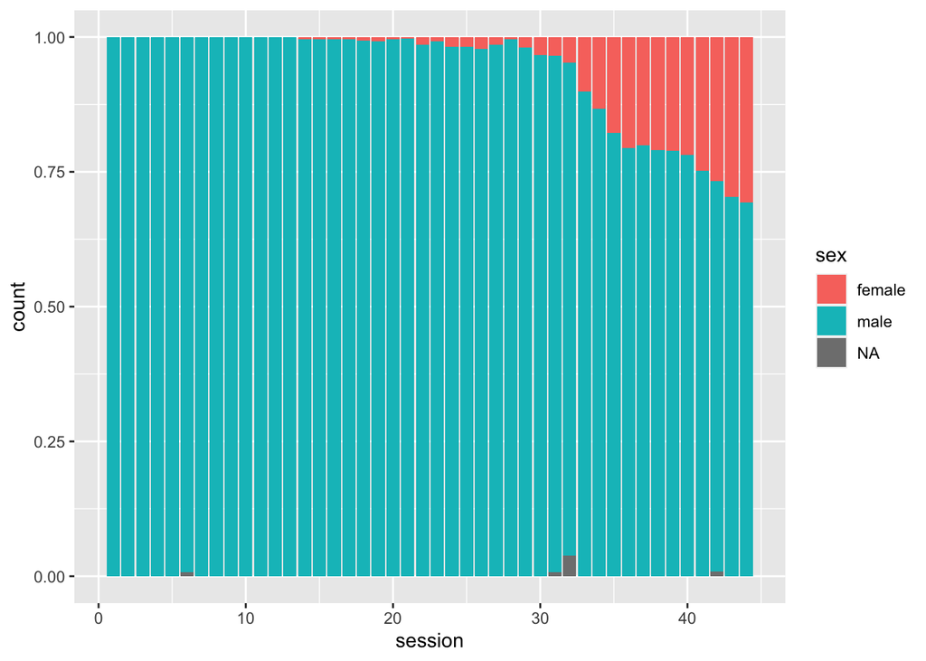

```r
can_core4 <- can_core %>% select (pageid, name, sex) #putting only required variables from the core dataset
can_core_pol <- full_join(can_core4, can_pol, by = "pageid") #merging two datasets
can_sex_ses <- data.frame(sex = can_core_pol$sex, session = can_core_pol$session) #creating separate dataframe for building plots
ggplot(data = can_sex_ses, aes(x = session, fill = sex)) + geom_bar(position = "fill")
```

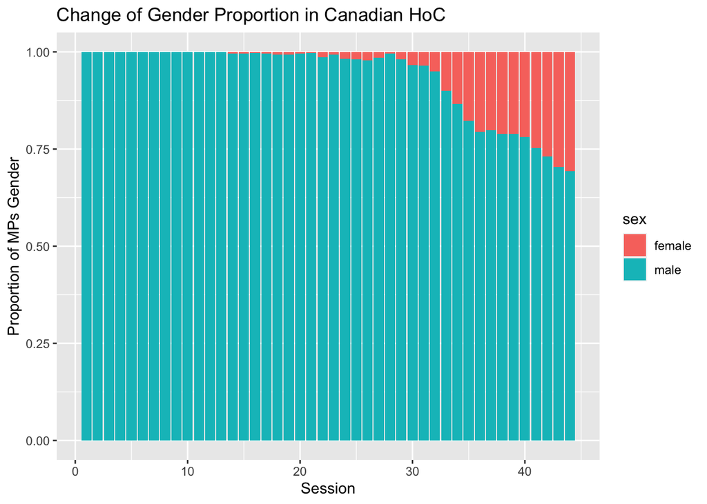

```r
can_sex_ses <- can_sex_ses %>% drop_na(sex) #removing blank data
ggplot(data = can_sex_ses, aes(x = session, fill = sex)) + geom_bar(position = "fill") +
  labs(x = "Session", y = "Proportion of MPs Gender", title = "Change of Gender Proportion in Canadian HoC")
```

2. Explore another relation of variables in the dataset. Your analysis should (i) use data from both the `core` and the `political` table and (ii) feature data from several sessions. Also, offer a brief description and interpretation of your findings!

```r
can_single_set <- full_join(can_core, can_pol, by = "pageid") #creating single dataset
sum(is.na(can_single_set$ethnicity))
```

```
[1] 7237
```

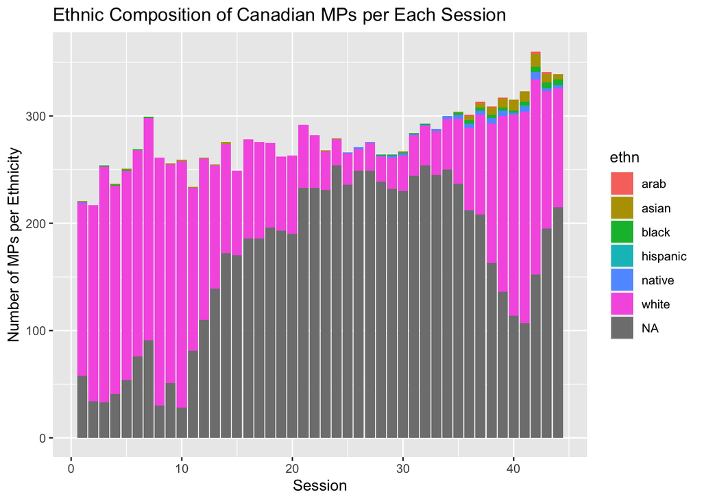

```r
ethn_mp <- data.frame(ethn = can_single_set$ethnicity, sess = can_single_set$session)
ggplot(data = ethn_mp, aes(x = sess, fill = ethn)) + geom_bar() + labs(x = "Session", y = "Number of MPs per Ethnicity", title = "Ethniс Composition of Canadian MPs per Each Session")
```

```r
#Due to high percent of blank values for ethnicity variable, using of absolute and relative values is not appropriate since it may lead to incorrect findings and interpretation
```

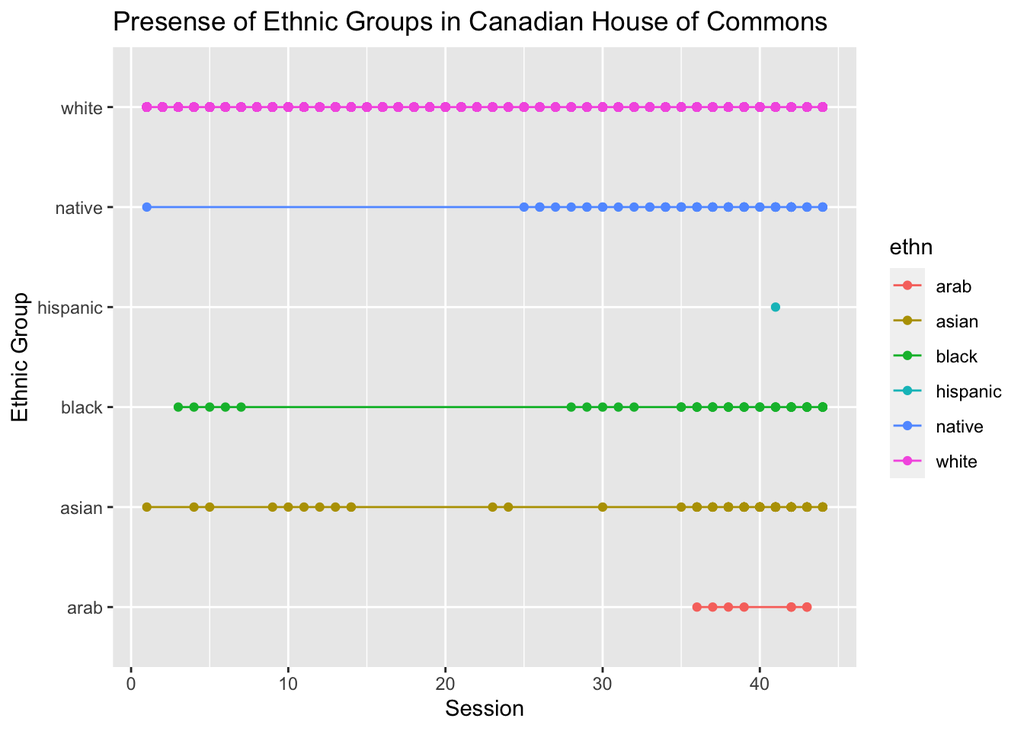

```r
ethn_mp_2 <- filter(ethn_mp,na.rm = TRUE)
ethn_mp_2 <- ethn_mp_2 %>% drop_na("ethn")
ggplot(data = ethn_mp_2, aes(x = sess, y = ethn, group = ethn, color = ethn)) +
  geom_line() + geom_point() + labs(
    title = "Presense of Ethnic Groups in Canadian House of Commons",
    x = "Session",
    y = "Ethnic Group")
```

```r
#Accordingly, the line plot showing presence of particular ethnic group in parliament session has been used
```

The line plot above showed presense of various ethnic group in session of Canadian House of Commons. It is worth to note that mainly white ethnic group was represented during first parliament sessions, and other groups were underrepresented. However, this situation changed significantly, and from around 25th session and later, members of parliament from different ethnic groups participated in sessions. It means that there were significant shift in diversity of parliament representation in Canada.